# Análise de atividade de parlamentares no twitter

Mateus de Lima Oliveira

28 de junho de 2019

```r
atividade = read_projectdata()

atividade = atividade %>%
  filter(!is.na(twitter), engaj_total > 0, engaj_mediano > 0, seguidores > 0, n_proprio > 0, n_retweet > 0)

atividade = atividade %>%
  mutate(seguidores_log = log10(seguidores),
         n_proprio_log = log10(n_proprio),
         n_retweet_log = log10(n_retweet),
         segue_log = log10(segue),
         engaj_total_log = log10(engaj_total),
         engaj_mediano_log = log10(engaj_mediano))
```

## 1. Qual a relação entre as características da atuação do parlamentar e o engajamento total que ele obtém no twitter?

### Analisando relação entre variaveis

Inicialmente iremos analisar como se dá a dispersão dos parlamentares em relação as variáveis de caracteristica (quantidade de seguidores, seguindo, retweets e twittes) para analisar possíveis correlações.

**Seguidores**

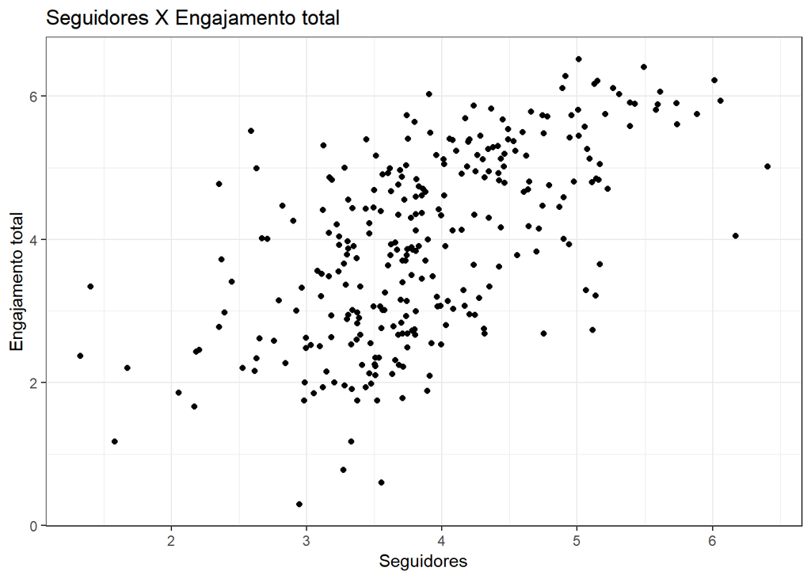

```r
atividade %>%
  ggplot(aes(y = engaj_total_log, x = seguidores_log))+
  geom_point()+
  labs(x = "Seguidores", y = "Engajamento total", title = "Seguidores X Engajamento total")
```

**Twittes**

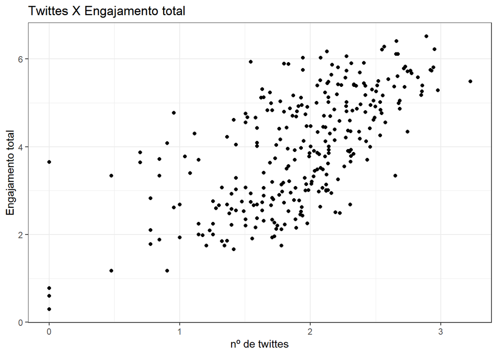

```r
atividade %>%
  ggplot(aes(y = engaj_total_log, x = n_proprio_log))+
  geom_point()+
  labs(x = "nº de twittes", y = "Engajamento total", title = "Twittes X Engajamento total")
```

**Retweet**

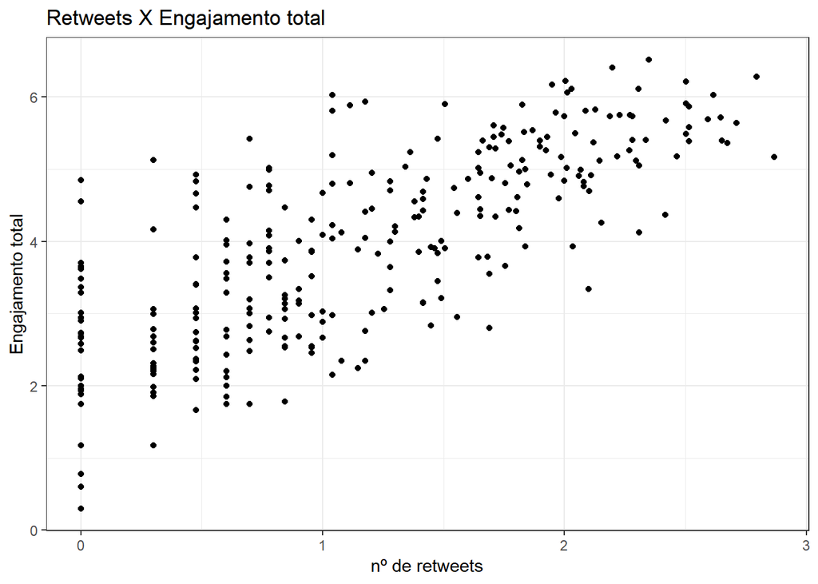

```r
atividade %>%
  filter(n_retweet > 0)%>%
  ggplot(aes(y = engaj_total_log, x = n_retweet_log))+
  geom_point()+
  labs(x = "nº de retweets", y = "Engajamento total", title = "Retweets X Engajamento total")
```

**Segue**

[figure not shown]

```r
atividade %>%
  filter(n_retweet > 0)%>%
  ggplot(aes(y = segue_log, x = n_retweet_log))+
  geom_point()+
  labs(x = "Seguindo", y = "Engajamento total", title = "Seguindo X Engajamento total")
```

### Estimando o modelo de regressão linear múltipla.

```r
lm_engaj_total <- lm(engaj_total_log ~ casa + segue_log + seguidores_log + n_proprio_log + n_retweet_log , data = atividade)

tidy(lm_engaj_total)
```

| term | estimate | std.error | statistic | p.value |
| --- | --- | --- | --- | --- |
| (Intercept) | 0.53211703 | 0.25527121 | 2.0845164 | 0.0380065920805386578407158992832 |
| casa2 | -0.06796713 | 0.10349138 | -0.6567419 | 0.5118786766340039928735450303066 |
| segue_log | -0.29008939 | 0.07526114 | -3.8544381 | 0.0001434890994657490675100175448 |
| seguidores_log | 0.56470768 | 0.05677662 | 9.9461311 | 0.0000000000000000000341599508191 |
| n_proprio_log | 0.53023522 | 0.09927969 | 5.3408225 | 0.0000001898576802071752152051981 |
| n_retweet_log | 0.86064824 | 0.07421486 | 11.5967110 | 0.0000000000000000000000001025894 |

```r
glance(lm_engaj_total)
```

| r.squared | adj.r.squared | sigma | statistic | p.value | df | logLik | AIC | BIC | deviance | df.residual |
| --- | --- | --- | --- | --- | --- | --- | --- | --- | --- | --- |
| 0.7161578 | 0.7111606 | 0.6987039 | 143.3112 | 0.000000000000000000000000000000000000000000000000000000000000000000000000001705103 | 6 | -304.4875 | 622.975 | 648.6642 | 138.6451 | 284 |

Considere **ET** = engajamento total, **CS** = casa do parlamentar, **RT** = número de retweets, **TP** = número de twittes próprios, **SG** = número de contas seguidas e **SGS** = número de seguidores. Além disso, o modelo foi gerado usando os dados com seu valor em log na base 10. Caso necessário, fazer a conversão para os valores originais.

### Ou seja..

O aumento de 1 unidade de RT (retweet) produz uma mudança de *0.86* no engajamento total, sendo a variável de maior influência no valor final de **ET**. Em contrapartida, a casa do parlamentar tem um menor impacto em seu engajamento, de *0.07*. A mesma lógica se aplica às demais variaveis.

## 2. Qual a relação entre as características da atuação do parlamentar e o *engajamento mediano* que ele obtém no twitter?

### Analisando relação entre variaveis

**Seguidores**

[figure not shown]

```r
atividade %>%
  ggplot(aes(y = engaj_mediano_log, x = seguidores_log))+
  geom_point()+
  labs(x = "Seguidores", y = "Engajamento total", title = "Seguidores X Engajamento total")
```

**Twittes**

[figure not shown]

```r
atividade %>%
  ggplot(aes(y = engaj_mediano_log, x = n_proprio_log))+
  geom_point()+
  labs(x = "nº de twittes", y = "Engajamento total", title = "Twittes X Engajamento total")
```

**Retweet**

[figure not shown]

```r
atividade %>%
  filter(n_retweet > 0)%>%
  ggplot(aes(y = engaj_mediano_log, x = n_retweet_log))+
  geom_point()+
  labs(x = "nº de retweets", y = "Engajamento total", title = "Retweets X Engajamento total")
```

**Segue**

[figure not shown]

```r
atividade %>%
  filter(n_retweet > 0)%>%
  ggplot(aes(y = engaj_mediano_log, x = segue_log))+
  geom_point()+
  labs(x = "seguindo", y = "Engajamento total", title = "Seguindo X Engajamento total")
```

### Estimando o modelo de regressão linear múltipla.

```r
lm_engaj_mediano <- lm(engaj_mediano_log ~ casa + segue_log + seguidores_log + n_proprio_log + n_retweet_log , data = atividade)

tidy(lm_engaj_mediano)
```

| term | estimate | std.error | statistic | p.value |
| --- | --- | --- | --- | --- |
| (Intercept) | -0.7867609 | 0.20770483 | -3.787880 | 0.000185470987572280542748925924456671054940670729 |
| casa2 | -0.1044584 | 0.08420714 | -1.240493 | 0.215816766227772016684127720509422942996025085449 |
| segue_log | -0.3410067 | 0.06123723 | -5.568617 | 0.000000059513432275486689917998184284897433826700 |
| seguidores_log | 0.7438113 | 0.04619705 | 16.100840 | 0.000000000000000000000000000000000000000006864527 |
| n_proprio_log | -0.1477701 | 0.08078025 | -1.829285 | 0.068405330220188950707260744366067228838801383972 |
| n_retweet_log | 0.2813467 | 0.06038591 | 4.659146 | 0.000004886049496595280645754033610472788495826535 |

```r
glance(lm_engaj_mediano)
```

| r.squared | adj.r.squared | sigma | statistic | p.value | df | logLik | AIC | BIC | deviance | df.residual |
| --- | --- | --- | --- | --- | --- | --- | --- | --- | --- | --- |
| 0.5728301 | 0.5653095 | 0.5685097 | 76.16818 | 0.00000000000000000000000000000000000000000000000001977974 | 6 | -244.687 | 503.374 | 529.0632 | 91.78974 | 284 |

Considere **EM** = engajamento mediano, **CS** = casa do parlamentar, **RT** = número de retweets, **TP** = número de twittes próprios, **SG** = número de contas seguidas e **SGS** = número de seguidores. Além disso, assim como o primeiro, o modelo foi gerado usando os dados com seu valor em log na base 10. Caso necessário, fazer a conversão para os valores originais.

## Ou seja..

Os resultados da regressão indicam o modelo no formato: **EM = *(0.28)*.RT + *(-0.14)*.TP + *(-0.3)*.SG + *0.74*.SGS *(-0.10)*.CS**, que explicaria **56,5%** da variância da variável de resposta (R² = 0.5653).

O aumento de 1 unidade de SGS (seguidores) produz uma mudança de *0.74* no engajamento mediano. Portanto, é a variável de maior influência no valor final de **EM**. Em contrapartida, assim como na primeira analise, a casa do parlamentar tem um menor impacto em seu engajamento, de *-0,10*. A mesma lógica se aplica às demais variaveis.